# Introdução ao R - Sessão 4.1

# 10. Combinação de gráficos

A combinação de gráficos numa mesma figura é facilitada pelo R através das funções **par()** e **layout()**. Com a função **par()** a combinação de gráficos é feita com a utilização do argumento **mfrow=c(nrows, ncols)** ou **mfcol=c(nrows, ncols)**. Com mfrow os gráficos são incluídos na matriz por linha, enquanto que com **mfcol** os gráficos são incluídos na matriz por coluna.

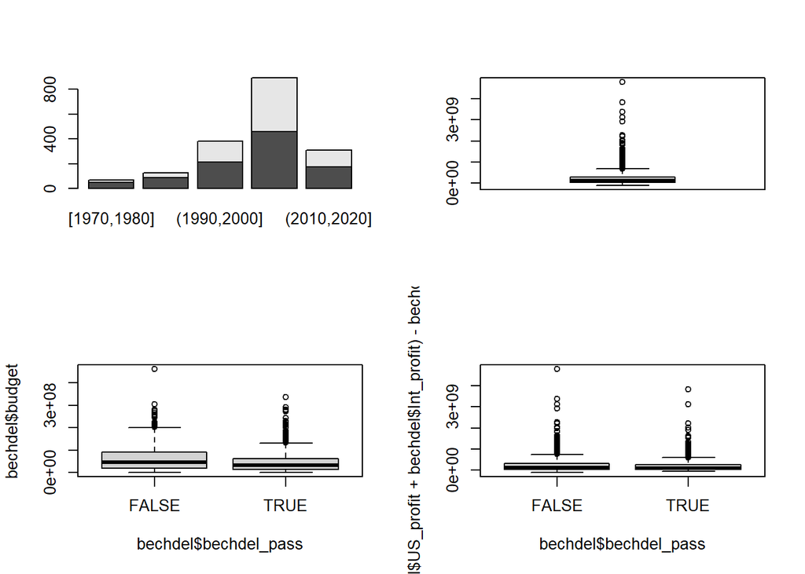

```r
par(mfrow=c(2,2))
barplot(table(bechdel$bechdel_pass, bechdel$year_fac))
boxplot((bechdel$US_profit+bechdel$Int_profit) - bechdel$budget)
boxplot(bechdel$budget~bechdel$bechdel_pass)
boxplot(((bechdel$US_profit+bechdel$Int_profit) - bechdel$budget)~bechdel$bechdel_pass)
```

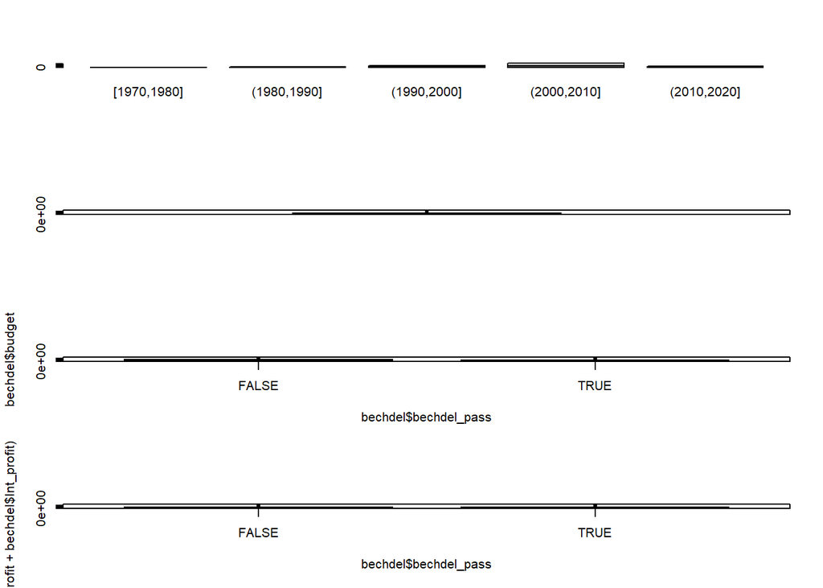

```r
par(mfrow=c(4,1))
barplot(table(bechdel$bechdel_pass, bechdel$year_fac))
boxplot((bechdel$US_profit+bechdel$Int_profit) - bechdel$budget)
boxplot(bechdel$budget~bechdel$bechdel_pass)
boxplot(((bechdel$US_profit+bechdel$Int_profit) - bechdel$budget)~bechdel$bechdel_pass)
```

A função layout() define uma matriz que é usada para mapear a figura onde são dispostos os gráficos. O argumento essencial da função layout() é uma matriz especificando o local dos diferentes gráficos.

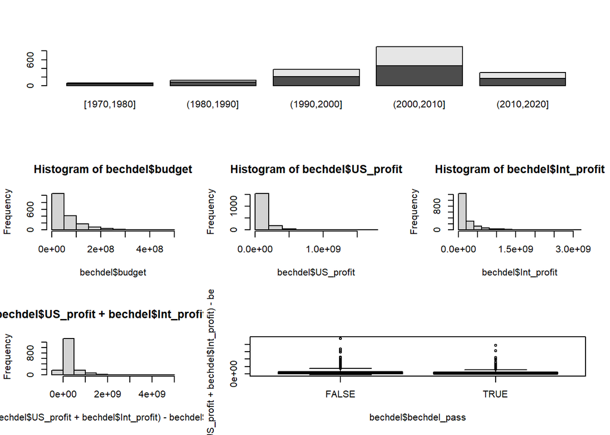

```r
layout(matrix(c(1,1,1,
              2,3,4,
              5,6,6), 3,3, byrow=TRUE))

barplot(table(bechdel$bechdel_pass, bechdel$year_fac))
hist(bechdel$budget)
hist(bechdel$US_profit)
hist(bechdel$Int_profit)
hist((bechdel$US_profit+bechdel$Int_profit) - bechdel$budget)
boxplot(((bechdel$US_profit+bechdel$Int_profit) - bechdel$budget)~bechdel$bechdel_pass)
```

A função layout() torna também possível definir a largura e altura dos diferentes gráficos, respetivamente com os argumentos widths e heights. Widths refere-se à largura das colunas, enquanto heights referes à altura das linhas

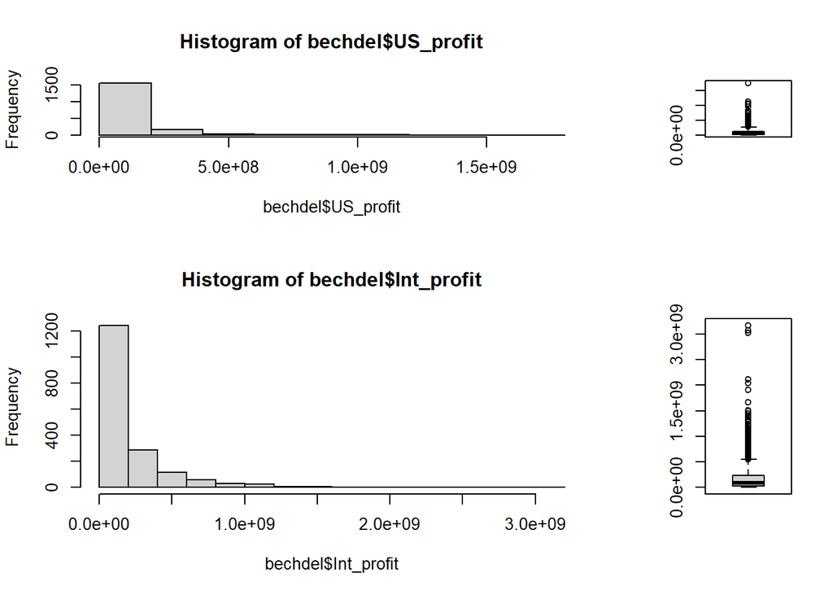

```r
layout(matrix(c(1,2,3,4), 2, 2, byrow=TRUE),
       widths=c(3,1), heights=c(.8,1.2))

hist(bechdel$US_profit)
boxplot(bechdel$US_profit)
hist(bechdel$Int_profit)
boxplot(bechdel$Int_profit)
```

Finalmente, é também possível manipular a disposição dos gráficos na figura utilizando o argumento fig da função par(). Este argumento permite definir localização e dimensões de diferentes gráficos numa mesma figura. O argumento genérico é fig=c(x1, x2, y1, y2). x1 e x2 representam a localização respetivamente de início e fim do objeto na figura no eixo dos x’s. y1 e y2 representam a localização respetivamente de início e fim do objeto na figura no eixo dos y’s.

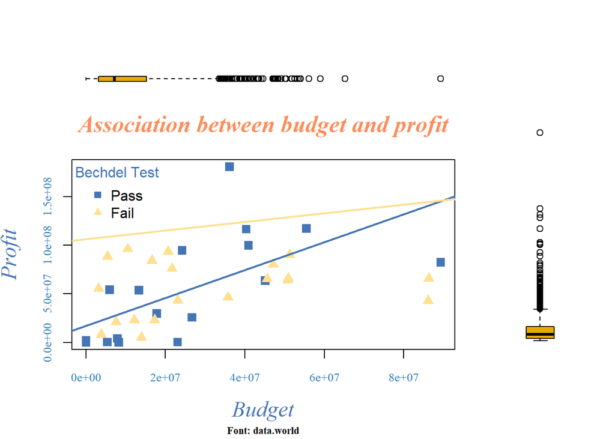

```r
par(fig=c(0,.8,0,.8))
plot(bechdel_samp$budget[bechdel_samp$bechdel_pass==TRUE], bechdel_samp$US_profit[bechdel_samp$bechdel_pass==TRUE], type="p",
     pch=15,
     col="#4575B4", col.axis ="#2C7BB6", col.lab="#4575B4", col.axis ="#2C7BB6", col.main="#FC8D59",
     main = "Association between budget and profit", sub = "Font: data.world", xlab = "Budget", ylab = "Profit",
     cex=1.3, cex.axis=.8, cex.lab=1.5, cex.main=1.6, cex.sub=.7,
     font.axis=1, font.lab=3, font.main=4, font.sub=2, family="serif")
points(bechdel_samp$budget[bechdel_samp$bechdel_pass==FALSE], bechdel_samp$US_profit[bechdel_samp$bechdel_pass==FALSE],
       type="p", pch=17, col="#FEE090", cex=1.3)
abline(lm(bechdel_samp$US_profit[bechdel_samp$bechdel_pass==TRUE] ~ bechdel_samp$budget[bechdel_samp$bechdel_pass==TRUE]), lty=1, lwd=2, col="#4575B4")
abline(lm(bechdel_samp$US_profit[bechdel_samp$bechdel_pass==FALSE] ~ bechdel_samp$budget[bechdel_samp$bechdel_pass==FALSE]), lty=1, lwd=2, col="#FEE090")
legend("topleft", title="Bechdel Test", pch=c(15, 17), col=c("#4575B4", "#FEE090"), c("Pass", "Fail"),
       bty = "n", title.col="#4575B4")

par(fig=c(0, .8, .6, 1), new=TRUE)
boxplot(bechdel$budget, col= brewer.pal(8, "Dark2")[6], horizontal=TRUE, axes=FALSE)

par(fig=c(.7, 1, 0, .88), new=TRUE)
boxplot(bechdel$US_profit, col= brewer.pal(8, "Dark2")[6], axes=FALSE)
```